# Principal Component Analysis

Sam Bowyer

2023-01-25

## Task 1

First we shall load the `USArrests` dataset and extract the three features of interest.

```r
data(USArrests)
X0 = USArrests[, c("Murder", "Assault", "Rape")]
head(X0)
```

|  | Murder | Assault | Rape |
| --- | --- | --- | --- |
| Alabama | 13.2 | 236 | 21.2 |
| Alaska | 10.0 | 263 | 44.5 |
| Arizona | 8.1 | 294 | 31.0 |
| Arkansas | 8.8 | 190 | 19.5 |
| California | 9.0 | 276 | 40.6 |
| Colorado | 7.9 | 204 | 38.7 |

Next we must center the data.

```r
X0 = as.matrix(X0)
n = nrow(X0)
p = ncol(X0)
C = diag(n) - matrix(rep(1/n,n*n), n)
X = C %*% X0
```

We can quickly check that indeed each feature now has zero mean (or at least very close to zero because of unavoidable floating point errors).

```r
mean(X[,"Murder"]); mean(X[,"Assault"]); mean(X[,"Rape"])
```

```
## [1] 1.213438e-15
```

```
## [1] -2.685581e-14
```

```
## [1] -1.674771e-15
```

Now we can find the principal components by calculating the covariance matrix and performing a spectral decomposition to obtain the eigenvalues and eigenvectors.

```r
# Covariance matrix
S = (1/n) * (t(X) %*% X)

# Spectral decomposition
decomp = eigen(S)
decomp
```

```
## eigen() decomposition
## $values
## [1] 6856.551123   47.685467    6.591443
##
## $vectors
##             [,1]        [,2]        [,3]
## [1,] -0.04180743  0.02555358  0.99879886
## [2,] -0.99630506 -0.07612980 -0.03975532
## [3,] -0.07502247  0.99677042 -0.02864195
```

```r
A = decomp$vectors
lambda = decomp$values

Y = X %*% A
```

The principal components are given by the columns of `Y` (in order from left to right).

```r
head(Y)
```

```
##            [,1]       [,2]      [,3]
## [1,]  -65.22280 -4.8603090  2.812779
## [2,]  -93.73728 16.2271656 -2.124128
## [3,] -123.53050  0.3621893 -4.867595
## [4,]  -19.08128 -3.1652836  0.295500
## [5,] -106.35485 11.3245200 -3.528043
## [6,]  -34.43236 14.8838930 -1.709919
```

To plot the two-dimensional reduction of the dataset we can simply use the first two columns of $Y$.

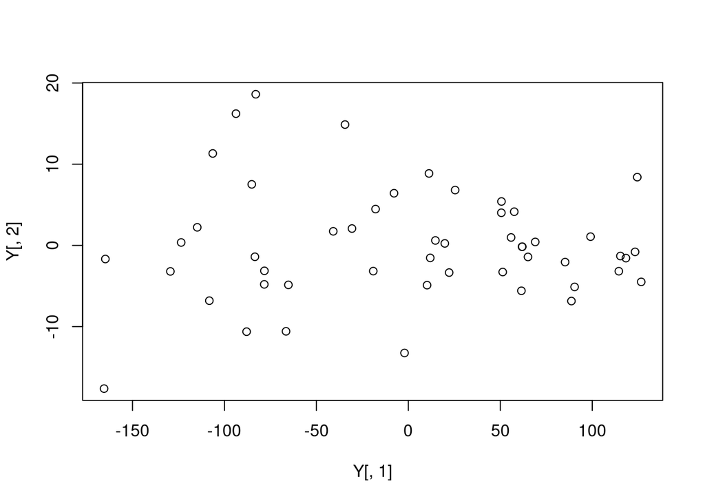

```r
plot(Y[,1], Y[,2])
```

Equivalently, PCA can be seen as projecting the original dataset onto the linear subspace spanned by the columns of `A`, which we can show by multiplying `X` and `A'` (where `Y'` only contains the first two columns of `A`, i.e. the first two principle components of `X`).

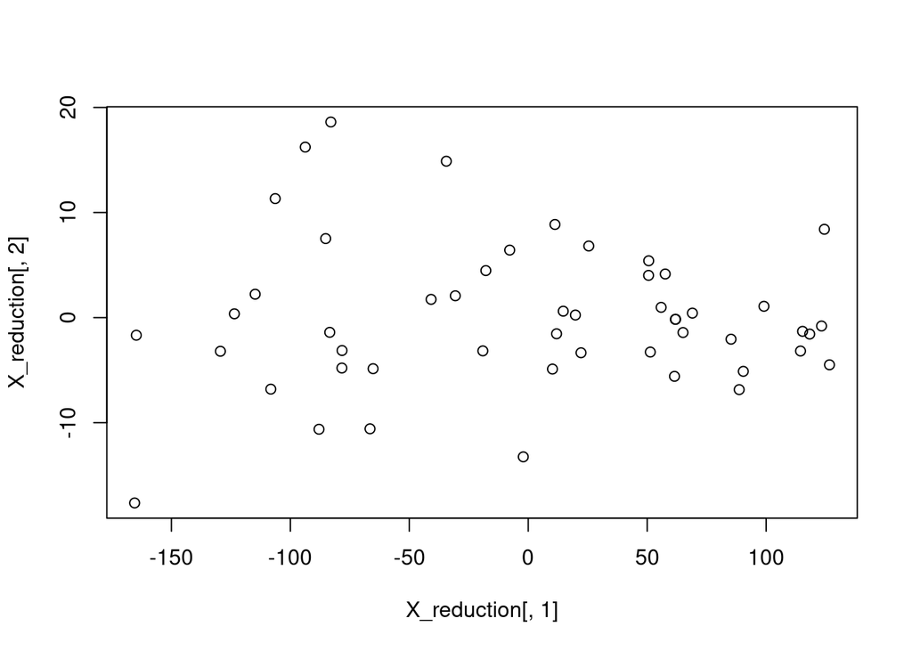

```r
X_reduction = X %*% A[,1:2]
plot(X_reduction[,1], X_reduction[,2])
```

```r
prcomp(X)
```

```
## Standard deviations (1, .., p=3):
## [1] 83.644968  6.975574  2.593446
##
## Rotation (n x k) = (3 x 3):
##                 PC1         PC2         PC3
## Murder  -0.04180743  0.02555358  0.99879886
## Assault -0.99630506 -0.07612980 -0.03975532
## Rape    -0.07502247  0.99677042 -0.02864195
```